# Relatório Sobre Mineração de Texto: Discurso the Luther King e Twitter

Rodolfo Viegas de Albuquerque

2022-08-22

[figure not shown]

# Relatório

Este relatório é para a disciplina de Análise de Dados para Computação, ministrada pelo professor Dr. Ermeson Andrade.

Será analisados o discurso do ativista americano Martin Luther King Jr., este discurso foi proferido em 1963, será criado uma gráfico de barras com as frequências de palavras e uma nuvem de palavras.

Além do discurso de Luther King, será criado uma nuvem de palavras por meio e tuítes com a *tag* Brasil e uma gráfico de barras com a análise de sentimento dessa massa e dados.

# Nuvem de Palavras do Discurso de Martin Luther King Jr.

O presente relatório utiliza a tradução do famoso discurso de Martin Luther King Jr. - “I have a Dream” - expresso em 28 de agosto de 1963 para gerar uma nuvem de palavras que ajuda a analisar o teor do texto. A presente tradução foi obtida pelo site [Brasil de Fato](https://www.brasildefato.com.br/2018/08/28/eu-tenho-um-sonho-ha-55-anos-martin-luther-king-proferia-discurso-historico/)

## Pré-processamento

O procedimento começa com a obtenção e carregamentos das bibliotecas básicas para manipulação e geração de nuvem:

```r
#importação
library(tm)
```

```r
library(wordcloud)
library(readr)
```

É possível fazer download do texto através e Webscrap, mas para facilitar a coleta simplesmente copia e cola o texto num editor de tua preferência e e o salva com o título “discurso_luther_king.txt”.

Após isso devemos carrega a massa de caracteres. Vamos criar uma variável chamada discurso e usar a função read_file, do pacote readr, para lê-la.

```r
discurso <- read_file("/home/rodolfoviegas/R_Scripts/Luther_Nuvem/discurso_luther_king.txt")
```

O texto de King não é grande, possuindo 9448 caracteres.

É possivel vizualizar os conteúdo da string:

```r
substr(discurso,1,1000)
```

```
## [1] "\"Estou feliz por estar hoje com vocês num evento que entrará para a história como a maior demonstração pela liberdade na história de nosso país.\r\n\r\nHá cem anos, um grande americano, sob cuja simbólica sombra nos encontramos, assinou a Proclamação da Emancipação. Esse decreto fundamental…
```

Podemos ver que há caracteres especiais de quebra de texto, como \n e \r\n. Tais símbolos não são relevantes à análise e devem ser descartados. Com a função gsub() podemos substitui-los por um espaço vázio, assim dando mais naturalidade às letras. Vamos atribuir uma nova variável nomeada ‘discurso2’:

```r
discurso2 <-gsub("\\r\\n\\r\\n"," ",discurso)
substr(discurso2,1,1000)
```

```
## [1] "\"Estou feliz por estar hoje com vocês num evento que entrará para a história como a maior demonstração pela liberdade na história de nosso país. Há cem anos, um grande americano, sob cuja simbólica sombra nos encontramos, assinou a Proclamação da Emancipação. Esse decreto fundamental foi co…
```

O discurso possui aparência mais agradável com a retiradas das quebras de texto.

### Transformação

Um passo fundamental para a criação a nuvem é transformar a massa de dados em um objetos ‘corpus’, este é gerado pelo biblioteca ‘tm’.

```r
vs <- VectorSource(discurso2)
corpus <- Corpus(vs)
```

Podemos verificar o objeto:

```r
inspect(corpus)
```

```
## <<SimpleCorpus>>
## Metadata:  corpus specific: 1, document level (indexed): 0
## Content:  documents: 1
##
## [1] "Estou feliz por estar hoje com vocês num evento que entrará para a história como a maior demonstração pela liberdade na história de nosso país. Há cem anos, um grande americano, sob cuja simbólica sombra nos encontramos, assinou a Proclamação da Emancipação. Esse decreto fundamental foi como…
```

Agora precisamos transformar a string para melhor analisá-la. Transformaremos os caracteres em minusculos, removeremos pontuações e palavras ruídos - que não possuem relevância para análise de nuvem. Além da remoção de espaços em branco. E podemos ver o resultado com a função ‘inspect’.

```r
corpus <- tm_map(corpus, content_transformer(tolower))

corpus <- tm_map(corpus,removePunctuation)

corpus <- tm_map(corpus,stripWhitespace)

corpus <- tm_map(corpus, removeNumbers)

corpus <- tm_map(corpus, removeWords, stopwords("portuguese"))
```

# Gráfico e Nuvem

## Gráfico de Barras

Uma forma de completar a análise é a utilização do gráfico de barras, este monstra a frequência das palavras na string já nos monstrano uma prévia da relevância dessas para o autor do discurso. A linguagem R possui um grande acervo de para visualização.

Comecemos criando uma matriz que carrega os caracteres, ela facilitará na criação no gráfico.

```r
matriz_frequencias <- as.matrix(TermDocumentMatrix(corpus))
```

Ao visualizarmo-la, notemos que essa não está com a frequência ordernada:

```r
matriz_frequencias[c(1:20),]
```

```
##       abriu    acabaram      acesso       achar acidentados   acontecer
##           1           1           1           1           1           1
##   acordarão   acreditar    adquirir       agora       ainda     alabama
##           1           2           1           6           6           3
##     algemas        algo      alguma      alguns   alicerces   allegheny
##           1           1           1           3           1           1
##        alma    alterada
##           1           1
```

Podemos ordená-la com a função sort.

```r
matriz_frequencias <- sort(rowSums(matriz_frequencias), decreasing = T)
```

Após verificarmos que a matriz não estava ordenada, notemos também que há uma enorme quantidade de palavras com frequência igual a 1. Eles têm pouca relevância para a visualização, então devemos selecionar as palavras com frequência mais elevadas, digamos acima de 3.

```r
aux <- subset(matriz_frequencias,matriz_frequencias>3)
```

Com isso tudo é suficiente para criármos nosso gráfico de barras. Para isso, usemos a função barplot():

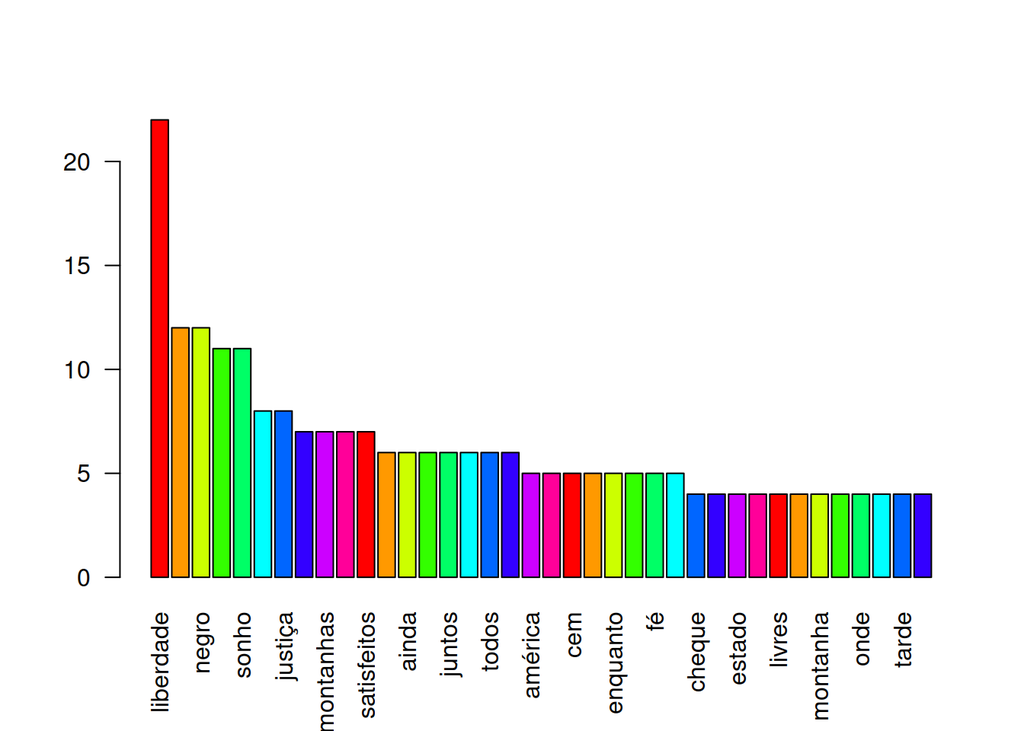

```r
barplot(aux, las=2, col=rainbow(10),)
```

Já com o gráfico podemos verificar a relevância de palavras como ‘liberadade’, que na cultura americana é bastante valorizada. Além do mais, no contexto das leis de Segregação, cidadão de pele negra - outra palavras que obviamente é relevante - não poderiam exercer sua liberdade com tais leis opressivas.

## Nuvem

Através da função wordcloud podemos gerar um nuvem. Para este trabalhos selecionaremos palavras com frequência mínima igual a 5 e a quantiade de palavras exposta com o máximo de 100.

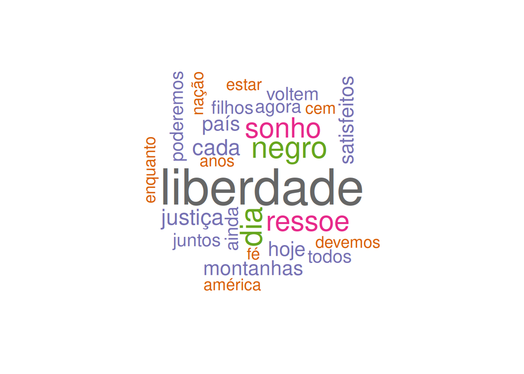

```r
wordcloud(words = corpus, min.freq = 5, max.words = 100,
          random.order = F, rot.per = 0.25,
          colors = brewer.pal(8,"Dark2"))
```

A nuvem de palavras reflete o gráfico de barras, monstrando de um modo mais intuitivo as frequências.

# Mineração de Tuítes

Com o passar do tempo, as redes sociais tornaram-se parte da rotina das pessoas. Lá não é só o local e conhecer novos amigos, mas um ponto de expressar opiniões e debater. Logo, essas redes são fontes importantes de dados para entender opiniões e sentimentos da população em relação as mais variádas coisas.

O Twitter oferece uma API para fazermos tratamento dos textos em 144 caracteres de lá.

## Nuvem de Tuítes

Primeiramente cria uma conta no Twitter e loga no Developer Twitter, lá as chaves para autenticação dos recursos da rede.

Carrega as principais bibliotecas:

```r
library(rtweet)
library(tm)
library(wordcloud)
library(RColorBrewer)
```

Tendo as chaves de autenticação, atribu-as em variáveis e as aplica na função “token” e roda a função “auth_setup_default”. Como isso, a autenticação será validada.

```r
consumer_key <- "ARWEMkx1S5O121fR2Rq55otBB"
consumer_secret <- "IHOrVvvUWLtHvB22dcKaVMxKbpfDcZafyvWe0cdPpQQrgBJggm"
access_token <- "1176572720001236992-qpxQcXUbwl0CcQSanWAdwdRsDYwvnv"
access_secret <- "PKtzdxaH7hT5J7VCGhLZASRFEi63fJghNNA329iJJqGCN"

token <- create_token(app= "TuiteLula",
                     consumer_key,
                     consumer_secret,
                     access_token,
                     access_secret)
```

```
## Saving auth to '/home/rodolfoviegas/.config/R/rtweet/create_token.rds'
```

```r
auth_setup_default()
```

```
## Using default authentication available.
## Reading auth from '/home/rodolfoviegas/.config/R/rtweet/default.rds'
```

Agora é hora de baixar os dados:

```r
rstat_tweets<-search_tweets("#Brasil", n=500,lang = "pt")

tweets<- paste(rstat_tweets$full_text, collapse = " ")
```

A biblioteca “rtweet”, através da função “search_tweets”, baixá-los e os armazena na estrutura data frame - mais fácil de analisar. Mas precisamos colapsá-los para uma string, afim de analisar os dados que queremos.

Semelhante a mineração de textos, precisamos limpar os dados para gerarmos nossa nuvem.

```r
tweets_S <- VectorSource(tweets)
corpus <- Corpus(tweets_S)



corpus <- tm_map(corpus, content_transformer(tolower))
# Remoção de putuação
corpus <- tm_map(corpus,removePunctuation)
# Remoção de espaços em branco a mais
corpus <- tm_map(corpus,stripWhitespace)
# Remoção de palavras ruído (stopwords)
corpus <- tm_map(corpus, removeWords, stopwords("portuguese"))



removeURL <- function(x){gsub("http[^[:space:]]*","",x)}
corpus<-tm_map(corpus,removeURL)

# remove qualquer coisa que nao seja letras em portugues e espaço
removeNumPunct<-function(x){gsub("[^[:alpha:][:space:]]*","",x)}
corpus<-tm_map(corpus,removeNumPunct)
```

É possível ainda verificar a frequencia as palavras para ajudar a compreenção da nuvem.

```r
dtm<-TermDocumentMatrix(corpus)
dtm<-as.matrix(dtm)

# Frequencia ordenada
fre<-sort(rowSums(dtm),decreasing = T)
```

O gráfico de barras expões essas:

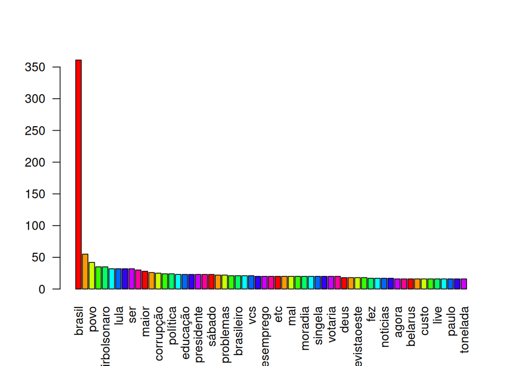

```r
aux <- subset(fre,fre>15)


# plotagem do gráfico de barras das frequência

barplot(aux, las=2, col=rainbow(10))
```

## Nuvem

A mesma função usada para nuvem em textos é usada para os tuítes:

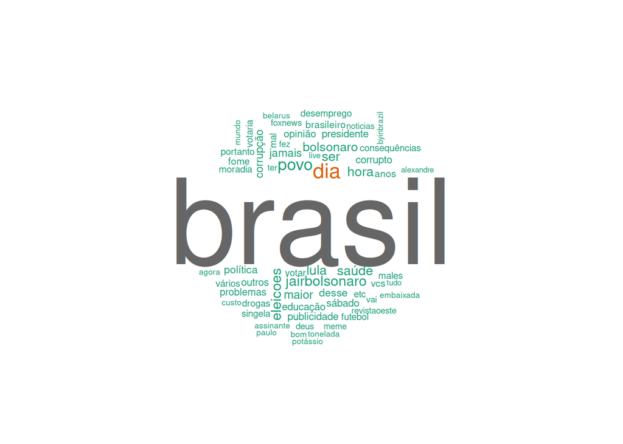

```r
wordcloud(words = corpus, min.freq = 15, max.words = Inf,
          random.order = F, rot.per = 0.15,
          colors = brewer.pal(8,"Dark2"),scale = c(8,.2))
```

## Análise de sentimentos

[figure not shown]

fonte: https://commons.wikimedia.org/wiki/File:Emoticon_angry-red.png#/media/File:Emoticon_angry-red.png

Além da nuvem de palavras, é possível desenvolvermos uma análise sentimentos em relação aos tuítes extraidos.

Comecemos pela biblioteca, se não a tens, usa a função “install.packages” para baixá-la:

```r
library(syuzhet)
```

Agora a função “get_nrc_sentiments” cria um data frame classificado os tuítes

```r
s<-get_nrc_sentiment(tweets)
```

Olhemos o dataframe

```r
head(s)
```

```
##   anger anticipation disgust fear joy sadness surprise trust negative positive
## 1     6           14       5   10  10       8        6    16       19       27
```

São várias coluna com sentimentos para classificarem os tuítes.

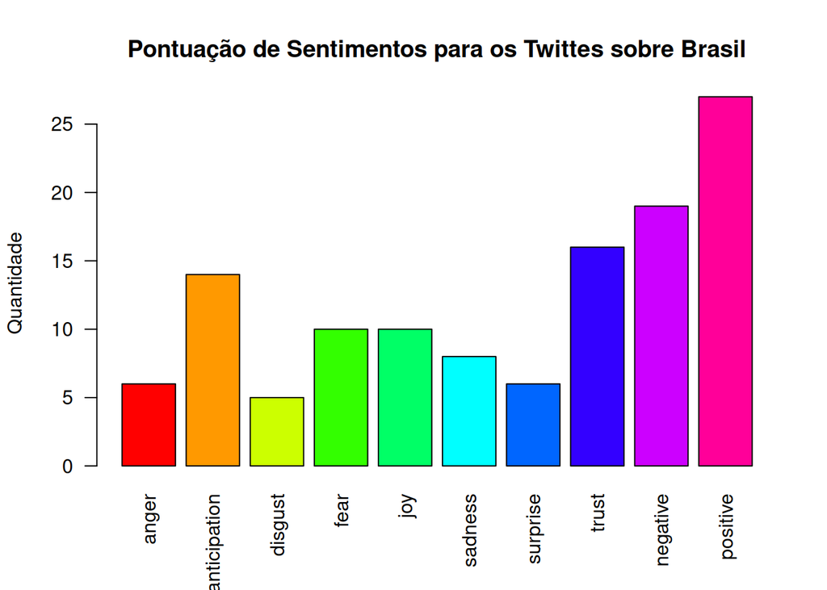

```r
barplot(colSums(s),las=2,col=rainbow(10),ylab= "Quantidade",main= "Pontuação de Sentimentos para os Twittes sobre Brasil")
```

# OFF (Caracateristicas no RMarkdown importantes)

## Uso do Latex

Uma das ferramentas mais usadas para criação de artigos científicos é o Latex, nele podemos criar textos com bom acabamento e desenvolver equações matemáticas complexas que teríamos dificuldade em editores mais populares.

É possível usá-lo dentro de RMarkdown; abaixo exemplos de equações escritas em LaTeX:

$$\int\limits_x^{\infty}\int\limits_b^{\infty}
x^2+y^2 \mathrm{d}x \mathrm{d}y$$

$$\binom{6}{4} = \frac{6!}{4! \cdot
2!}$$
$$A \bigcup B = \left\{ x \in
\mathbb{R} \middle| x \in A \bigvee x \in B \right\}$$

## Uso de Referências em RMarkdown

Referência com RMarkdown pode ser feitas pelo BibTex. Para adicionar, é preciso criar no cabeçalho do arquivo .Rmd o campo “bibliography”, nele coloca o caminho até o arquivo .bib com todas as refências usadas no artigo. Abaixo alguns exemplos:

### **Referências**

Ge, Vazquez, and Gretzel (2017) Zimbra et al. (2018) Solovyev et al. (2019) Yu et al. (2018) Kumar and Jain (2015)

Ge, Jing, Marisol Alonso Vazquez, and Ulrike Gretzel. 2017. “Sentiment Analysis: A Review.” *Advances in Social Media for Travel, Tourism and Hospitality*, 243–61.

Kumar, Alok, and Renu Jain. 2015. “Sentiment Analysis and Feedback Evaluation.” In *2015 IEEE 3rd International Conference on MOOCs, Innovation and Technology in Education (MITE)*, 433–36. IEEE.

Solovyev, Valery, Marina Solnyshkina, Elzara Gafiyatova, Danielle McNamara, and Vladimir Ivanov. 2019. “Sentiment in Academic Texts.” In *2019 24th Conference of Open Innovations Association (FRUCT)*, 408–14. IEEE.

Yu, Liang-Chih, Cheng-Wei Lee, HI Pan, Chih-Yueh Chou, Po-Yao Chao, ZH Chen, SF Tseng, CL Chan, and K Robert Lai. 2018. “Improving Early Prediction of Academic Failure Using Sentiment Analysis on Self-Evaluated Comments.” *Journal of Computer Assisted Learning* 34 (4): 358–65.

Zimbra, David, Ahmed Abbasi, Daniel Zeng, and Hsinchun Chen. 2018. “The State-of-the-Art in Twitter Sentiment Analysis: A Review and Benchmark Evaluation.” *ACM Transactions on Management Information Systems (TMIS)* 9 (2): 1–29.